# Desigualdad de Oportunidad en México

Análisis con ESRU-EMOVI 2023

Eduardo

24 de January de 2026

# Resumen Ejecutivo

Este estudio analiza la **Desigualdad de Oportunidad (IOp)** en México utilizando datos de la Encuesta ESRU-EMOVI 2023.

> **¿Qué proporción de la desigualdad de ingresos se debe a circunstancias fuera del control individual?**

## Hallazgo Principal

| Modelo | IOp | Nota |
| --- | --- | --- |
| Random Forest | 52.6% | Estimación principal |
| XGBoost | 53.5% | Con SHAP |
| Árbol de Decisión | 55.4% | 58 tipos |
| Gradient Boosting | 56.8% | Mayor R² |

**Conclusión:** Aproximadamente **52-57% de la desigualdad de ingresos** en México se debe a circunstancias fuera del control individual.

# Resultados por Circunstancia

## Educación de la Madre

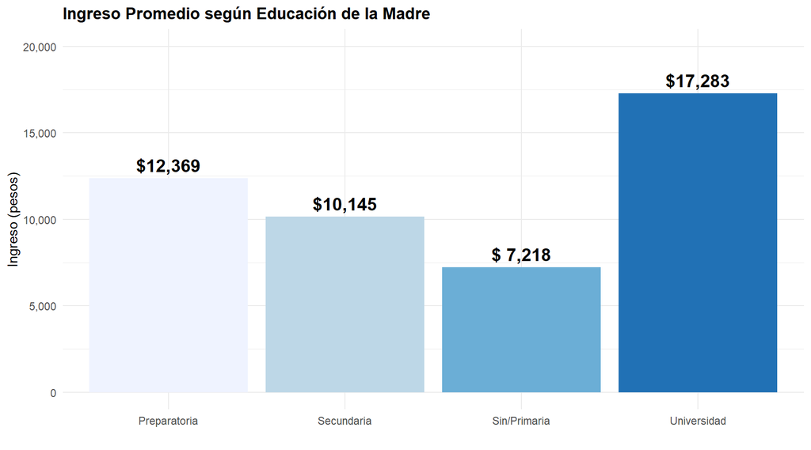

| Educación Madre | Ingreso Promedio |
| --- | --- |
| Sin/Primaria | $ 7,218 |
| Secundaria | $10,145 |
| Preparatoria | $12,369 |
| Universidad | $17,283 |

**Interpretación:** Una persona cuya madre tiene **universidad** gana **$17,283** vs **$7,218** de quien tiene madre sin primaria. Eso es **2.4 veces más**.

## Educación del Padre

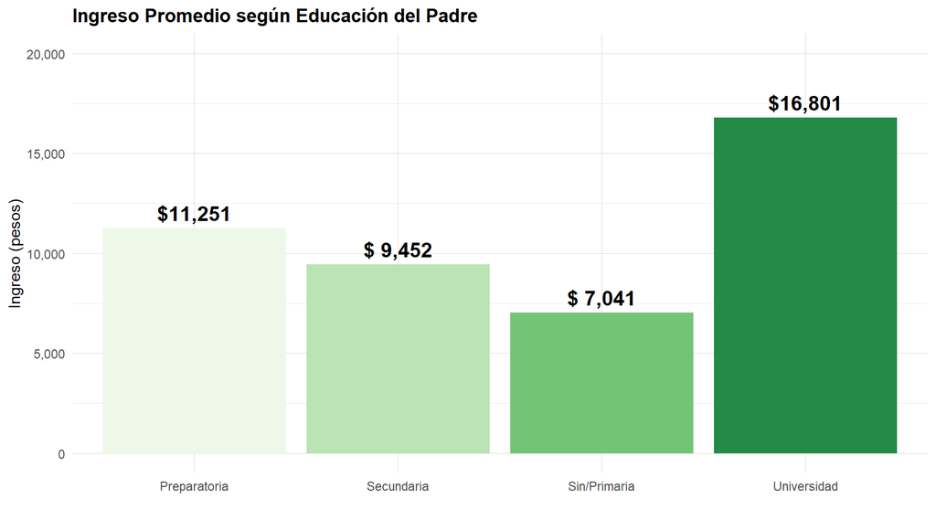

## Sexo

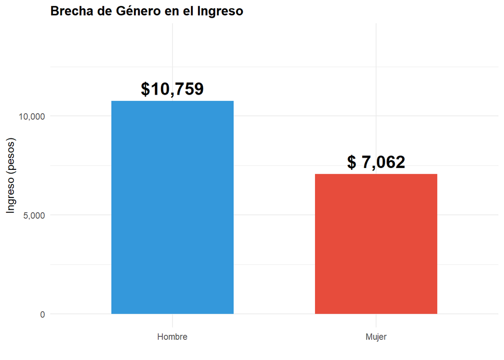

**Brecha de género:** Los hombres ganan **$3,697 pesos más** que las mujeres en promedio (1.5x más).

## Región a los 14 años

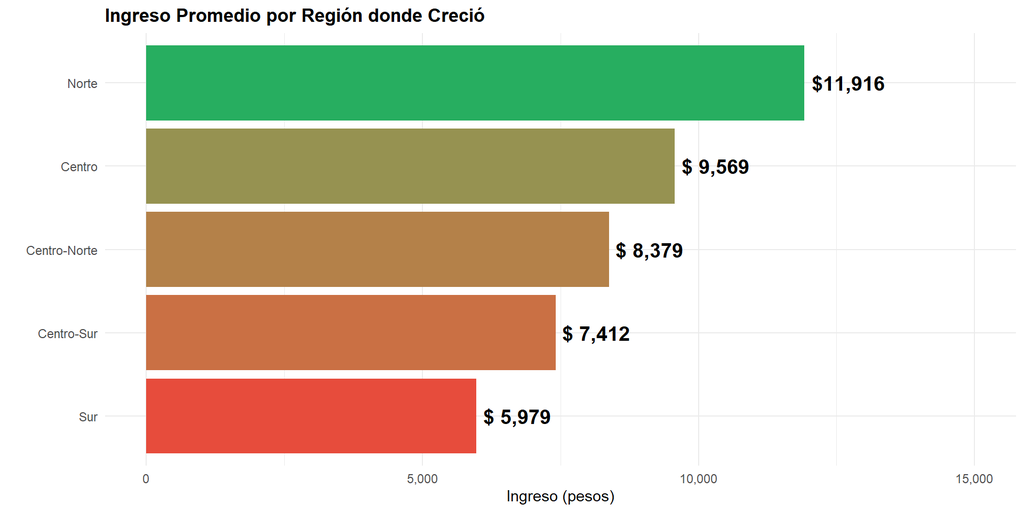

**Interpretación:** Crecer en el **Norte** vs el **Sur** significa ganar **$5,937 pesos más** (2.0x).

## Rural / Urbano

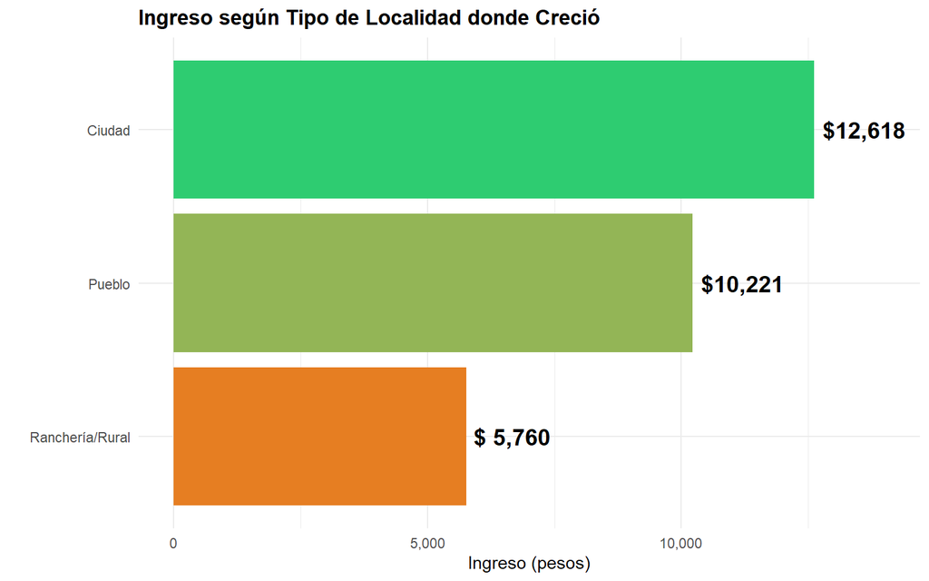

**Interpretación:** Crecer en **ciudad** vs **zona rural** significa ganar **2.2x más** ($6,858 de diferencia).

## Ocupación del Padre

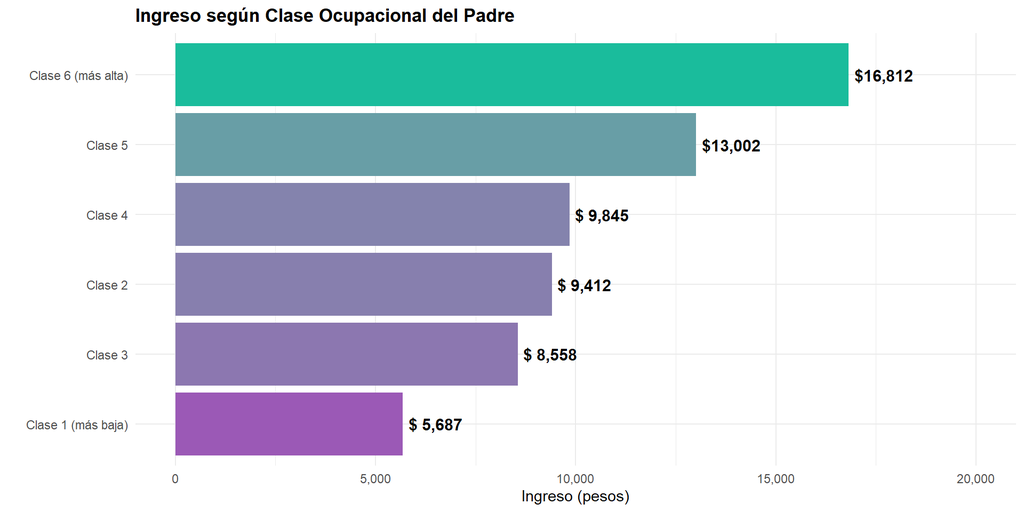

**Interpretación:** Hijos de padres en **clase alta** ganan **3.0x más** que hijos de padres en clase baja.

## Lengua Indígena

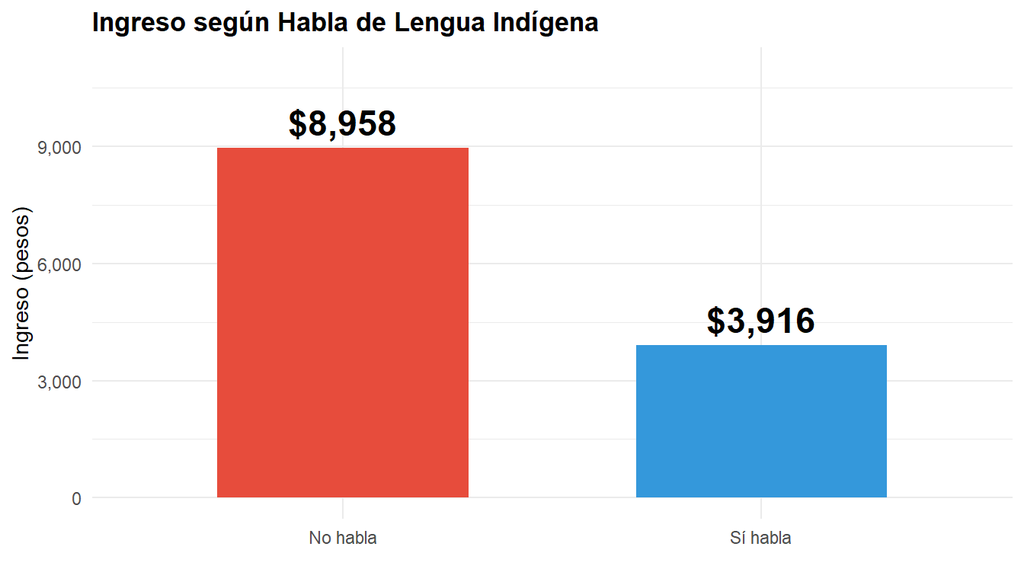

**Interpretación:** Quienes **no hablan** lengua indígena ganan **2.3x más** ($5,042 de diferencia).

# Resumen de Brechas

| Circunstancia | Brecha (veces) | Diferencia en pesos |
| --- | --- | --- |
| Clase ocupacional padre (Alta vs Baja) | 3.0 | $11,125 |
| Educación madre (Universidad vs Sin primaria) | 2.4 | $10,065 |
| Educación padre (Universidad vs Sin primaria) | 2.4 | $9,760 |
| Lengua indígena (No vs Sí) | 2.3 | $5,042 |
| Localidad (Ciudad vs Rural) | 2.2 | $6,858 |
| Región (Norte vs Sur) | 2.0 | $5,937 |
| Sexo (Hombre vs Mujer) | 1.5 | $3,697 |

# Conclusiones

1. **Más de la mitad (52-57%)** de la desigualdad de ingresos en México se debe a circunstancias fuera del control individual.
2. Los **factores más importantes** son:
   - Clase ocupacional del padre (3.0x)
   - Educación de los padres (2.4x)
   - Condición indígena (2.3x)
   - Localidad rural/urbana (2.2x)
3. Las **mayores brechas** se observan en:
   - Clase ocupacional del padre: **$11,125 de diferencia**
   - Educación de la madre: **$10,065 de diferencia**
   - Educación del padre: **$9,760 de diferencia**

# Implicaciones de Política

Para reducir la desigualdad de oportunidad se necesitan políticas enfocadas en:

- **Educación**: Especialmente de mujeres y en zonas marginadas
- **Desarrollo regional**: Reducir brechas Norte-Sur
- **Equidad de género**: Cerrar la brecha salarial
- **Primera infancia**: Intervenciones tempranas

# Referencias

- Brunori, P., Ferreira, F. H., & Peragine, V. (2023). Inequality of opportunity. *Journal of Economic Inequality*.
- Monroy-Gómez-Franco, L. (2023). Ex-ante Inequality of Opportunity across Mexican Regions. *Economics Bulletin*.
- CEEY (2023). Encuesta ESRU de Movilidad Social en México (EMOVI) 2023.

*Análisis realizado con R. Datos: ESRU-EMOVI 2023.*